# Act Report

## Questions

- Tweet ID with the highest favourite count and retweet count
- The most common dog type
- Number of Tweets per month

### Tweet ID with the highest favourite count and retweet count

```python
import pandas as pd
# Import the archived master data
df1 = pd.read_csv('twitter_archive_master.csv')
df1.head(1)
```

|  | tweet_id | timestamp | source | text | retweeted_status_user_id | retweeted_status_timestamp | expanded_urls | rating_numerator | rating_denominator | name | dog_type | favorite_count | retweet_count |
| --- | --- | --- | --- | --- | --- | --- | --- | --- | --- | --- | --- | --- | --- |
| 0 | 892420643555336193 | 2017-08-01 16:23:56+00:00 | <a href="http://twitter.com/download/iphone" r... | This is Phineas. He's a mystical boy. Only eve... | NaN | NaN | https://twitter.com/dog_rates/status/892420643... | 13 | 10 | Phineas | NaN | 33703.0 | 6973.0 |

```python
df1.iloc[df1['favorite_count'].idxmax()]
```

```
tweet_id                                                     744234799360020481
timestamp                                             2016-06-18 18:26:18+00:00
source                        <a href="http://twitter.com/download/iphone" r...
text                          Here's a doggo realizing you can stand in a po...
retweeted_status_user_id                                                    NaN
retweeted_status_timestamp                                                  NaN
expanded_urls                 https://twitter.com/dog_rates/status/744234799...
rating_numerator                                                             13
rating_denominator                                                           10
name                                                                        NaN
dog_type                                                                  doggo
favorite_count                                                         144301.0
retweet_count                                                           70353.0
Name: 1011, dtype: object
```

```python
df1.iloc[df1['retweet_count'].idxmax()]
```

```
tweet_id                                                     744234799360020481
timestamp                                             2016-06-18 18:26:18+00:00
source                        <a href="http://twitter.com/download/iphone" r...
text                          Here's a doggo realizing you can stand in a po...
retweeted_status_user_id                                                    NaN
retweeted_status_timestamp                                                  NaN
expanded_urls                 https://twitter.com/dog_rates/status/744234799...
rating_numerator                                                             13
rating_denominator                                                           10
name                                                                        NaN
dog_type                                                                  doggo
favorite_count                                                         144301.0
retweet_count                                                           70353.0
Name: 1011, dtype: object
```

The `tweet_id` : `744234799360020481` has the highest favourite count of `144301` and retweet count of `70353`.

### The most common dog type

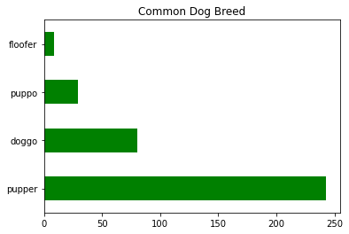

```python
df1[df1.dog_type.notna()]['dog_type'].value_counts().plot(kind='barh', title='Common Dog Breed', color='green');
```

Pupper is the most common dog type.

### Number of Tweets per Month

```python
# Select the year and month from the timestamp using string slicing
df1['time_df'] = df1['timestamp'].str[:7]

# Aggregate the number of tweets per month.
tweet_time = df1.groupby('time_df', as_index=False)['time_df'].value_counts()
```

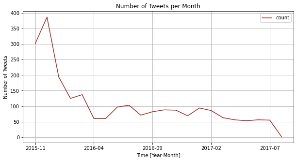

```python
# Plot the tweet time on a line chart
tweet_time.plot(x='time_df', y='count', xlabel='Time [Year-Month]',
                ylabel='Number of Tweets', title='Number of Tweets per Month', grid=True, color='brown', figsize=(10, 5));
```

The number of tweets by `weratedogs` per month has a decreasing trend over the years.

## Conclusion

From the analysis above, the `tweet_id`: `744234799360020481` has the highest favourites and the most retweet. The dog type is a `doggo` which happens to be the second most popular dog type in the dataset and it has a rating of `13/10`. `Pupper` is the most popular dog type in the dataset with a value count of almost 250 which is more than twice the value count of `doggo`. The `WeRateDogs` twitter page has a decreasing number of tweets over the years. It has a steep drop between the year 2015 and 2016.

## Limitations

- There were null values in the dataset that are dropped.
- Some observations are invalid and were dropped in the process of wrangling.